# FDI datacall Report

Compiled on 21/10/2022, 14:33

# 1 FDI catch data (Table A)

## 1.1 Check the presence of empty fiels

FDI catch data (table A) were checked for the presence of not allowed empty data. In case empty fields are detected, a list of fields with the number of emty records is reported.’

*Table of empty records in FDI catch table (Table A)*

|  | Empty_records |
| --- | --- |
| mesh_size_range | 446 |
| eez_indicator | 2413 |
| specon_tech | 3 |
| totwghtlandg | 30 |
| totvallandg | 33 |

## 1.2 Check the presence of duplicated records

FDI catch data (table A) were checked for the presence of duplicated records. In particular, it was checks whether the combination of the first 19 columns generates duplicate records.’

- 2 duplicated record/s was/were detected in the FDI catch table A

*Table of duplicated records in FDI catch table (Table A)*

|  | country | year | quarter | vessel_length | fishing_tech | gear_type | target_assemblage | mesh_size_range | metier | domain_discards | domain_landings | sub_region | species |
| --- | --- | --- | --- | --- | --- | --- | --- | --- | --- | --- | --- | --- | --- |
| 153 | PSP | 2019 | 1 | VL2440 | PMP | GNS | DEF | NK | GNS_DEF_>=16_0_0 | NK | NK | GSA99 | SWA |
| 641 | PSP | 2018 | 1 | VL1218 | PMP | NK | NK | NK | NK | NK | NK | GSA99 | SLM |

## 1.3 Coverage of FDI catch data by GSA and year

FDI catch data (table A) were analysed to report a summary table of the data coverage in terms of number of records by country, GSA and year.’

*Summary table of number of records by country, GSA and year (Table A).*

| year | country | gsa | records |
| --- | --- | --- | --- |
| 2014 | PSP | GSA99 | 429 |
| 2015 | PSP | GSA99 | 258 |
| 2016 | PSP | GSA99 | 258 |
| 2017 | PSP | GSA99 | 301 |
| 2018 | PSP | GSA99 | 387 |
| 2019 | PSP | GSA99 | 430 |
| 2020 | PSP | GSA99 | 387 |

## 1.4 Cross-coverage of landing and discard data in FDI catch table

The FDI catch table was analyzed to return plots for three variables (Total live weight landed (ton), total value of landings (euro), and total discards (ton)) grouped by year, vessels length, and fishing techniques.

### 1.4.1 GSA99

#### 1.4.1.1 HKE

Plot of total landing by year for HKE - PSP - GSA99

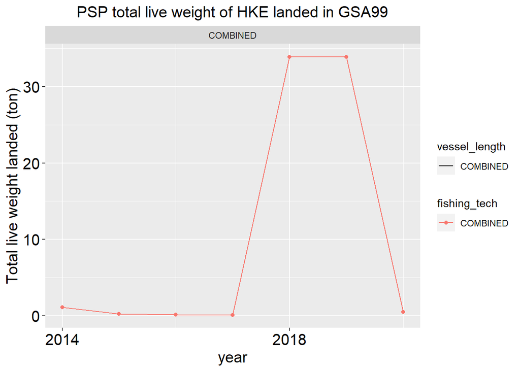

Plot of total value by year for HKE - PSP - GSA99

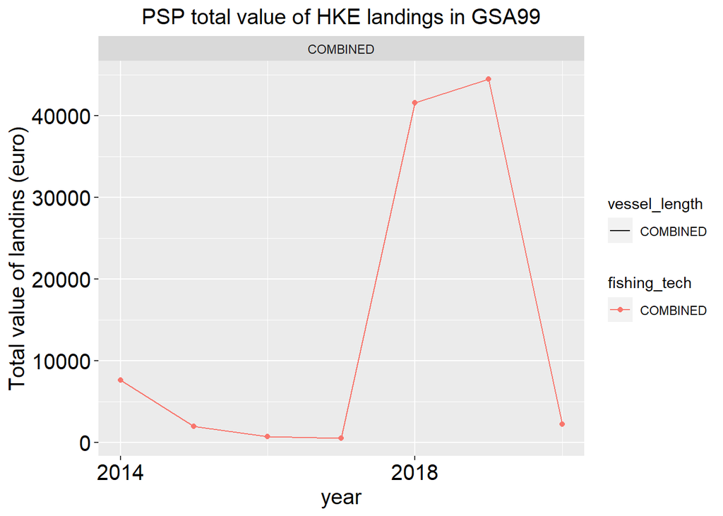

Plot of total discard by year for HKE - PSP - GSA99

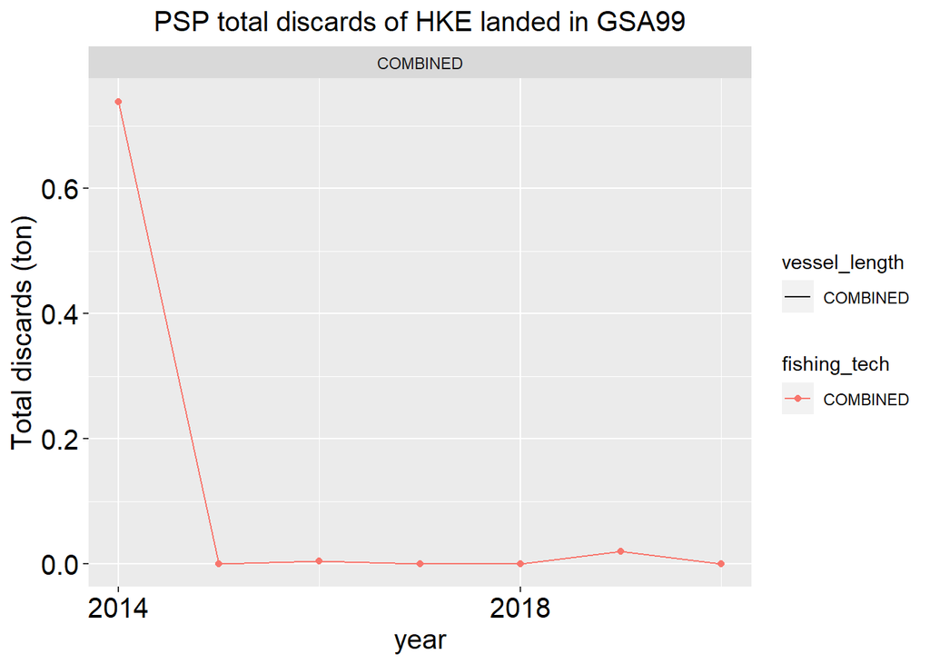

#### 1.4.1.2 DPS

Plot of total landing by year for DPS - PSP - GSA99

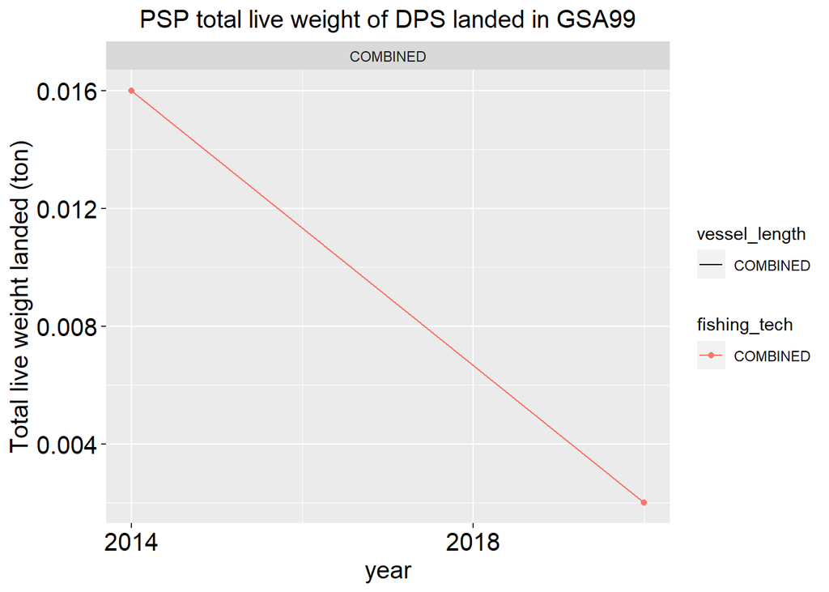

Plot of total value by year for DPS - PSP - GSA99

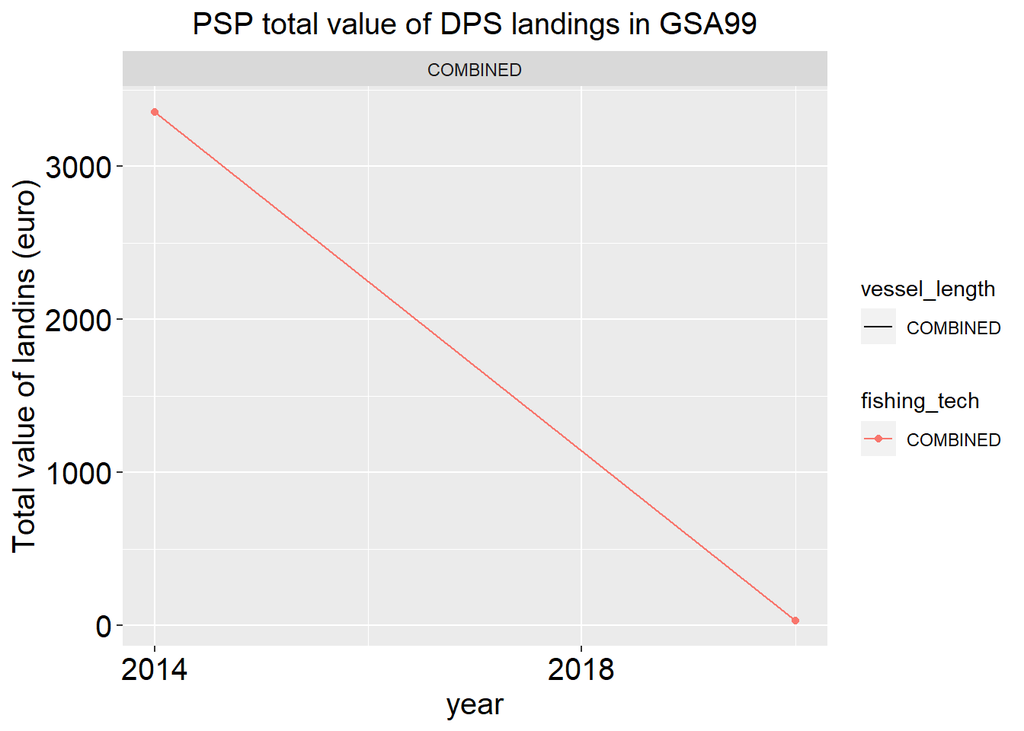

Plot of total discard by year for DPS - PSP - GSA99

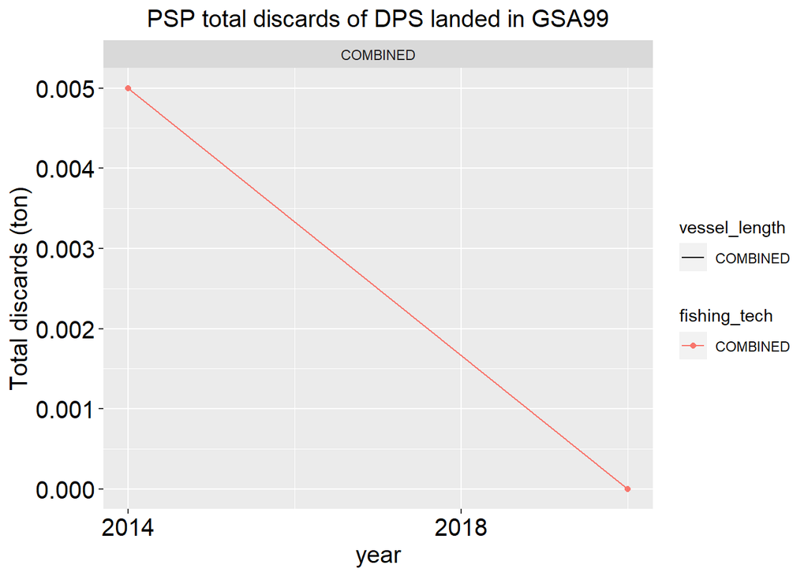

## 1.5 Cross-coverage of landing and discard data in FDI catch table A

The FDI catch table was analyzed to return a summary table reporting the amount and relative percentage of landings taking into account the availability of discard data by year (discard >0, =0 and =NK).

### 1.5.1 GSA99

#### 1.5.1.1 HKE

*Summary table landing amount and relative percentage accounting for discard availability for HKE in GSA99*

| year | gsa | Total_lands | Lands_(disc > 0) | % Lands_(disc >0) | Lands_(disc = 0) | % Lands_(disc = 0) | Lands_(disc = NK) | % Lands_(disc = NK) |
| --- | --- | --- | --- | --- | --- | --- | --- | --- |
| 2014 | GSA99 | 1.099 | 0.305 | 27.75% | 0.192 | 17.47% | 0.602 | 54.78% |
| 2015 | GSA99 | 0.249 | 0.000 | 0 | 0.000 | 0 | 0.249 | 100.00% |
| 2016 | GSA99 | 0.152 | 0.110 | 72.37% | 0.000 | 0 | 0.042 | 27.63% |
| 2017 | GSA99 | 0.088 | 0.000 | 0 | 0.032 | 36.36% | 0.056 | 63.64% |
| 2018 | GSA99 | 33.917 | 0.000 | 0 | 0.046 | 0.14% | 33.871 | 99.86% |
| 2019 | GSA99 | 33.907 | 0.044 | 0.13% | 0.000 | 0 | 33.863 | 99.87% |
| 2020 | GSA99 | 0.485 | 0.000 | 0 | 0.000 | 0 | 0.485 | 100.00% |

#### 1.5.1.2 DPS

*Summary table landing amount and relative percentage accounting for discard availability for DPS in GSA99*

| year | gsa | Total_lands | Lands_(disc > 0) | % Lands_(disc >0) | Lands_(disc = 0) | % Lands_(disc = 0) | Lands_(disc = NK) | % Lands_(disc = NK) |
| --- | --- | --- | --- | --- | --- | --- | --- | --- |
| 2014 | GSA99 | 0.016 | 0.016 | 100.00% | 0.000 | 0 | 0 | 0 |
| 2020 | GSA99 | 0.002 | 0.000 | 0 | 0.002 | 100.00% | 0 | 0 |

## 1.6 Species value

The FDI catch table was analyzed to return the estimates of the average price per species and year, that is further compared with the average price calculated per country (by species). Furthermore, in order to compare total weight landings and total value landings, the cases with total landings > 0 but landings value = 0 were identified and reported in a table, were available.

### 1.6.1 GSA99

#### 1.6.1.1 HKE

- No data available with landings > 0 and landings value = 0 for HKE - PSP - GSA99

*Summary table of avarage prices by year in HKE in GSA99*

| species | year | land weight | land value | price | av_price |
| --- | --- | --- | --- | --- | --- |
| HKE | 2014 | 1.099 | 7607.1731 | 6.921905 | 4.596886 |
| HKE | 2015 | 0.249 | 1944.6006 | 7.809641 | 4.596886 |
| HKE | 2016 | 0.152 | 709.8665 | 4.670174 | 4.596886 |
| HKE | 2017 | 0.088 | 495.4508 | 5.630123 | 4.596886 |
| HKE | 2018 | 33.917 | 41572.5541 | 1.225714 | 4.596886 |
| HKE | 2019 | 33.907 | 44517.1845 | 1.312920 | 4.596886 |
| HKE | 2020 | 0.485 | 2234.7473 | 4.607726 | 4.596886 |

#### 1.6.1.2 DPS

- No data available with landings > 0 and landings value = 0 for DPS - PSP - GSA99

*Summary table of avarage prices by year in DPS in GSA99*

| species | year | land weight | land value | price | av_price |
| --- | --- | --- | --- | --- | --- |
| DPS | 2014 | 0.016 | 3356.76758 | 209.79797 | 112.4677 |
| DPS | 2020 | 0.002 | 30.27467 | 15.13734 | 112.4677 |

## 1.7 Species’ prices trend

Plots by species and sub-region were generated to check the trends of the prices time series.

### 1.7.1 GSA99

#### 1.7.1.1 HKE

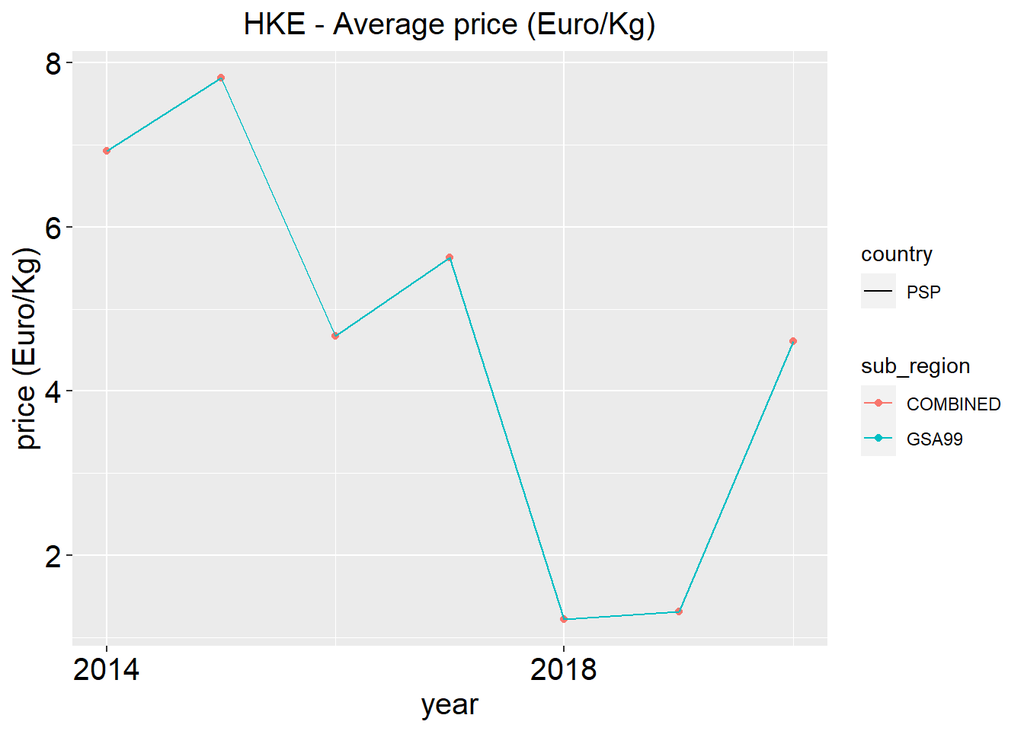

*Summary table of species’ prices by year for HKE in GSA99*

| year | country | sub_region | species | totwghtlandg | totvallandg | mean_price |
| --- | --- | --- | --- | --- | --- | --- |
| 2014 | PSP | GSA99 | HKE | 1.099 | 7607.1731 | 6.921905 |
| 2015 | PSP | GSA99 | HKE | 0.249 | 1944.6006 | 7.809641 |
| 2016 | PSP | GSA99 | HKE | 0.152 | 709.8665 | 4.670174 |
| 2017 | PSP | GSA99 | HKE | 0.088 | 495.4508 | 5.630123 |
| 2018 | PSP | GSA99 | HKE | 33.917 | 41572.5541 | 1.225714 |
| 2019 | PSP | GSA99 | HKE | 33.907 | 44517.1845 | 1.312920 |
| 2020 | PSP | GSA99 | HKE | 0.485 | 2234.7473 | 4.607726 |

#### 1.7.1.2 DPS

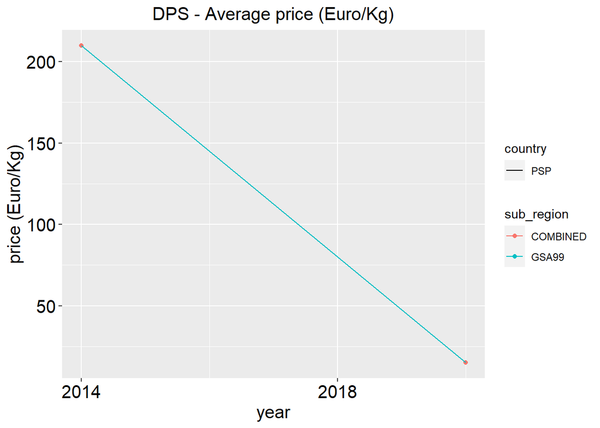

*Summary table of species’ prices by year for DPS in GSA99*

| year | country | sub_region | species | totwghtlandg | totvallandg | mean_price |
| --- | --- | --- | --- | --- | --- | --- |
| 2014 | PSP | GSA99 | DPS | 0.016 | 3356.76758 | 209.79797 |
| 2020 | PSP | GSA99 | DPS | 0.002 | 30.27467 | 15.13734 |

# 2 FDI effort data (table G)

## 2.1 Check the presence of empty fiels

FDI effort data (table G) were checked for the presence of not allowed empty records. In case empty data are detected, a list of fields with the number of empty records is reported.’

*Table of empty records in FDI effort table (Table G)*

|  | Empty_records |
| --- | --- |
| mesh_size_range | 446 |
| eez_indicator | 2413 |
| totgtdaysatsea | 18 |
| totfishdays | 18 |
| totkwfishdays | 79 |
| totgtfishdays | 103 |
| hrsea | 18 |
| kwhrsea | 18 |
| gthrsea | 18 |

## 2.2 Check the presence of duplicated records

FDI effort data (table G) were checked for the presence of duplicated records. In particular, it was checks whether the combination of the first 15 columns generates duplicate records.’

- 668 duplicated record/s was/were detected in the FDI effort table G

*Table of duplicated records in FDI effort table (Table G)*

|  | country | year | quarter | vessel_length | fishing_tech | gear_type | target_assemblage | mesh_size_range | metier | sub_region | specon_tech | deep |
| --- | --- | --- | --- | --- | --- | --- | --- | --- | --- | --- | --- | --- |
| 42 | PSP | 2019 | 1 | VL1824 | PMP | GNS | DEF | NK | GNS_DEF_>=16_0_0 | GSA99 | NK | NA |
| 43 | PSP | 2019 | 1 | VL2440 | PMP | GNS | DEF | NK | GNS_DEF_>=16_0_0 | GSA99 | NK | NA |
| 44 | PSP | 2019 | 1 | VL0006 | PMP | GNS | DEF | NK | GNS_DEF_>=16_0_0 | GSA99 | NK | NA |
| 45 | PSP | 2019 | 1 | VL0612 | PMP | GNS | DEF | NK | GNS_DEF_>=16_0_0 | GSA99 | NK | NA |
| 46 | PSP | 2019 | 1 | VL1218 | PMP | GNS | DEF | NK | GNS_DEF_>=16_0_0 | GSA99 | NK | NA |
| 52 | PSP | 2020 | 1 | VL1824 | PMP | GNS | DEF | NK | GNS_DEF_>=16_0_0 | GSA99 | NK | NA |
| 53 | PSP | 2020 | 1 | VL2440 | PMP | GNS | DEF | NK | GNS_DEF_>=16_0_0 | GSA99 | NK | NA |
| 54 | PSP | 2020 | 1 | VL0006 | PMP | GNS | DEF | NK | GNS_DEF_>=16_0_0 | GSA99 | NK | NA |
| 55 | PSP | 2020 | 1 | VL0612 | PMP | GNS | DEF | NK | GNS_DEF_>=16_0_0 | GSA99 | NK | NA |
| 61 | PSP | 2014 | 1 | VL1218 | PMP | GNS | DEF | NK | GNS_DEF_>=16_0_0 | GSA99 | NK | NA |
| 62 | PSP | 2014 | 1 | VL1824 | PMP | GNS | DEF | NK | GNS_DEF_>=16_0_0 | GSA99 | NK | NA |
| 63 | PSP | 2014 | 1 | VL2440 | PMP | GNS | DEF | NK | GNS_DEF_>=16_0_0 | GSA99 | NK | NA |
| 69 | PSP | 2015 | 1 | VL0006 | PMP | GNS | DEF | NK | GNS_DEF_>=16_0_0 | GSA99 | NK | NA |
| 75 | PSP | 2016 | 1 | VL0612 | PMP | GNS | DEF | NK | GNS_DEF_>=16_0_0 | GSA99 | NK | NA |
| 81 | PSP | 2017 | 1 | VL1218 | PMP | GNS | DEF | NK | GNS_DEF_>=16_0_0 | GSA99 | NK | NA |
| 82 | PSP | 2017 | 1 | VL1824 | PMP | GNS | DEF | NK | GNS_DEF_>=16_0_0 | GSA99 | NK | NA |
| 84 | PSP | 2018 | 1 | VL0006 | PMP | GNS | DEF | NK | GNS_DEF_>=16_0_0 | GSA99 | NK | NA |
| 85 | PSP | 2018 | 1 | VL0612 | PMP | GNS | DEF | NK | GNS_DEF_>=16_0_0 | GSA99 | NK | NA |
| 87 | PSP | 2018 | 1 | VL1824 | PMP | GNS | DEF | NK | GNS_DEF_>=16_0_0 | GSA99 | NK | NA |
| 88 | PSP | 2018 | 1 | VL2440 | PMP | GNS | DEF | NK | GNS_DEF_>=16_0_0 | GSA99 | NK | NA |
| 89 | PSP | 2018 | 1 | VL0006 | PMP | GNS | DEF | NK | GNS_DEF_>=16_0_0 | GSA99 | NK | NA |
| 90 | PSP | 2018 | 1 | VL0612 | PMP | GNS | DEF | NK | GNS_DEF_>=16_0_0 | GSA99 | NK | NA |
| 91 | PSP | 2018 | 1 | VL1218 | PMP | GNS | DEF | NK | GNS_DEF_>=16_0_0 | GSA99 | NK | NA |
| 92 | PSP | 2019 | 1 | VL1824 | PMP | GNS | DEF | NK | GNS_DEF_>=16_0_0 | GSA99 | NK | NA |
| 93 | PSP | 2019 | 1 | VL2440 | PMP | GNS | DEF | NK | GNS_DEF_>=16_0_0 | GSA99 | NK | NA |
| 94 | PSP | 2019 | 1 | VL0006 | PMP | GNS | DEF | NK | GNS_DEF_>=16_0_0 | GSA99 | NK | NA |
| 95 | PSP | 2019 | 1 | VL0612 | PMP | GNS | DEF | NK | GNS_DEF_>=16_0_0 | GSA99 | NK | NA |
| 98 | PSP | 2019 | 1 | VL2440 | PMP | GNS | DEF | NK | GNS_DEF_>=16_0_0 | GSA99 | NK | NA |
| 100 | PSP | 2019 | 1 | VL0612 | PMP | GNS | DEF | NK | GNS_DEF_>=16_0_0 | GSA99 | NK | NA |
| 102 | PSP | 2020 | 1 | VL1824 | PMP | GNS | DEF | NK | GNS_DEF_>=16_0_0 | GSA99 | NK | NA |

[output cut: 638 more lines]

## 2.3 Coverage of FDI effort data by GSA and year

FDI effort data (table G) were analysed to report a summary table of the data coverage in terms of number of records by country, GSA and year.’

*Summary table of number of records by country, GSA and year (Table G).*

| year | country | gsa | records |
| --- | --- | --- | --- |
| 2014 | PSP | GSA99 | 429 |
| 2015 | PSP | GSA99 | 258 |
| 2016 | PSP | GSA99 | 258 |
| 2017 | PSP | GSA99 | 301 |
| 2018 | PSP | GSA99 | 387 |
| 2019 | PSP | GSA99 | 430 |
| 2020 | PSP | GSA99 | 387 |

## 2.4 Coverage of Fishing effort in FDI table G

The FDI effort table G was analyzed to return plots for the following 8 variables:

1. Total days at sea;
2. Total Fishing Days;
3. Total kW * days at Sea;
4. total GT * days at sea;
5. Total kW * fishing days;
6. Total GT * fishing days;
7. Hours at Sea;
8. Total kW * hours at sea.

### 2.4.1 GSA99

Plot of Total days at sea for PSP - GSA99

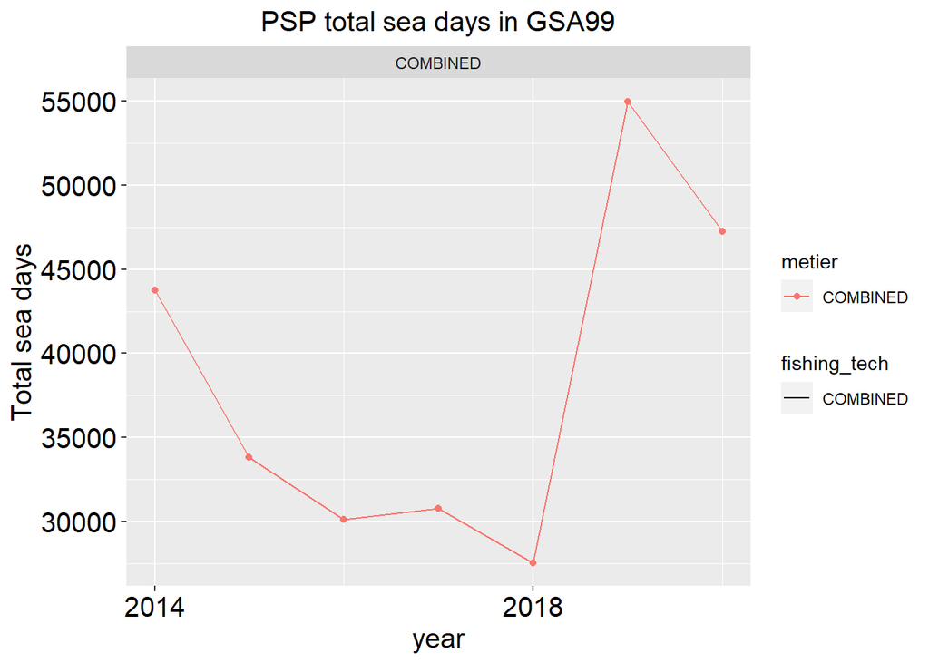

Plot of Total Fishing Days for PSP - GSA99

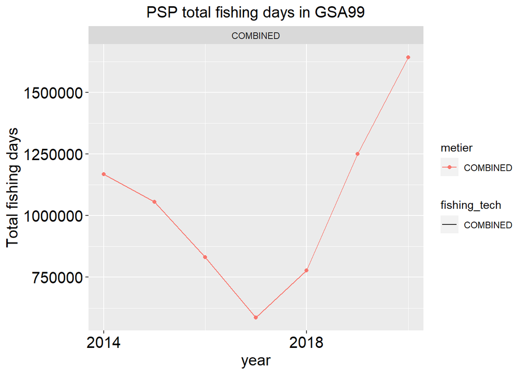

Plot of Fishing effort in Total kW times days at Sea for PSP - GSA99

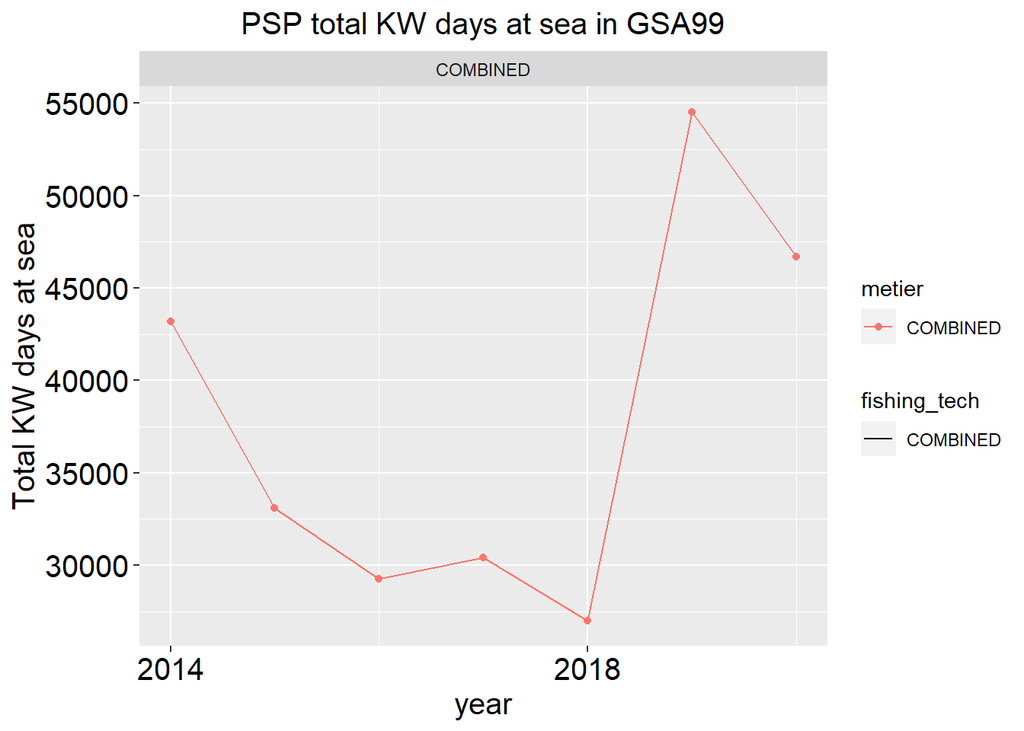

Plot of Fishing effort in total GT times days at sea for PSP - GSA99

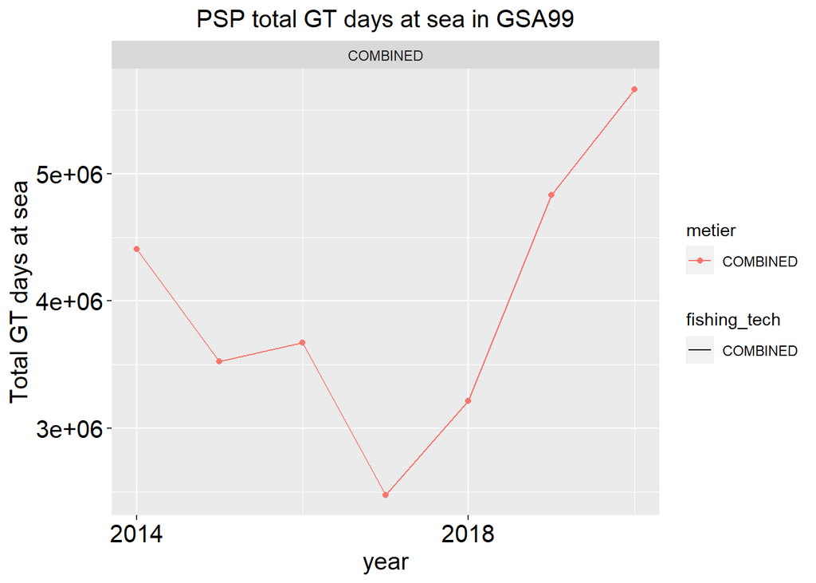

Plot of Fishing effort in kW times fishing days for PSP - GSA99

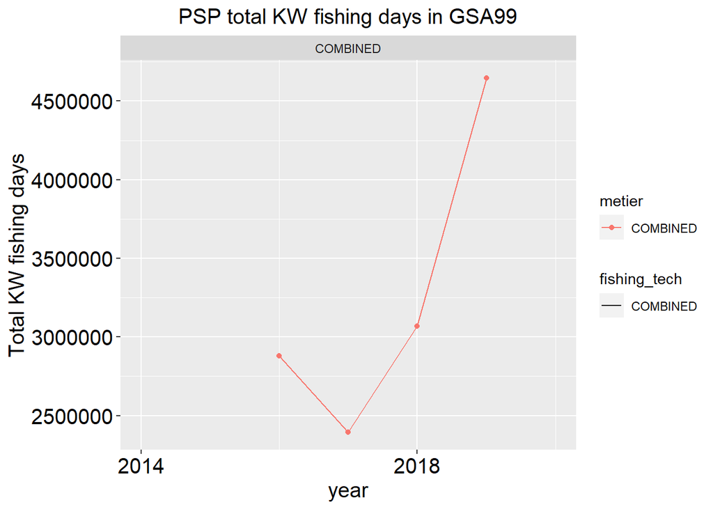

Plot of Fishing effort in gross tonnage times fishing days for PSP - GSA99

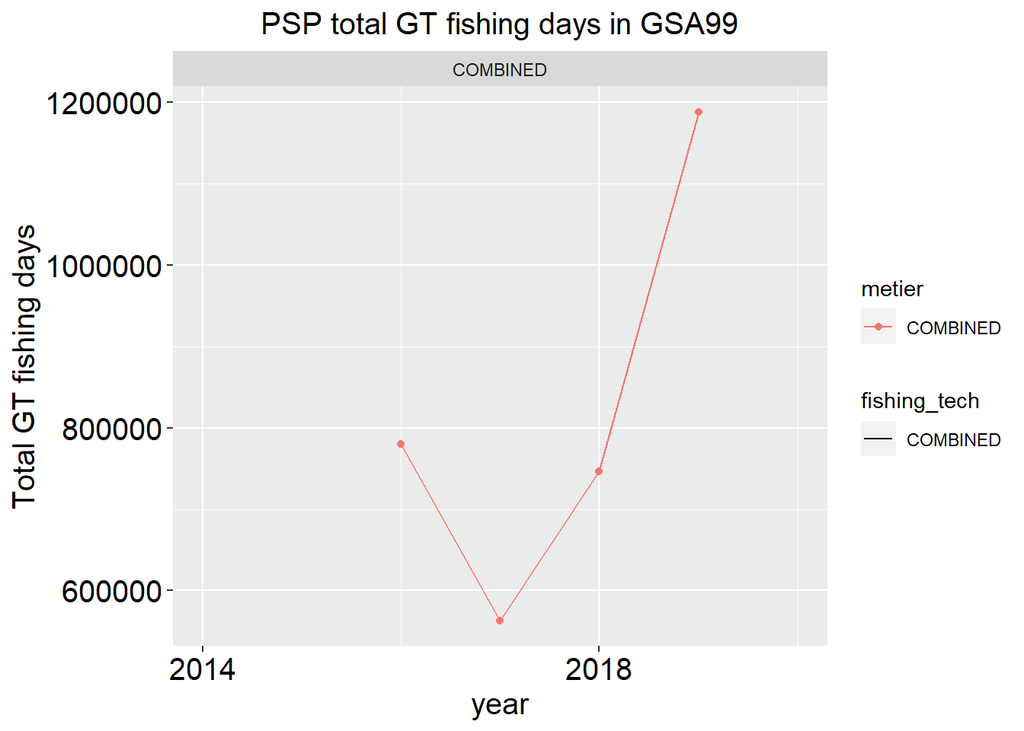

Plot of Hours at Sea for PSP - GSA99

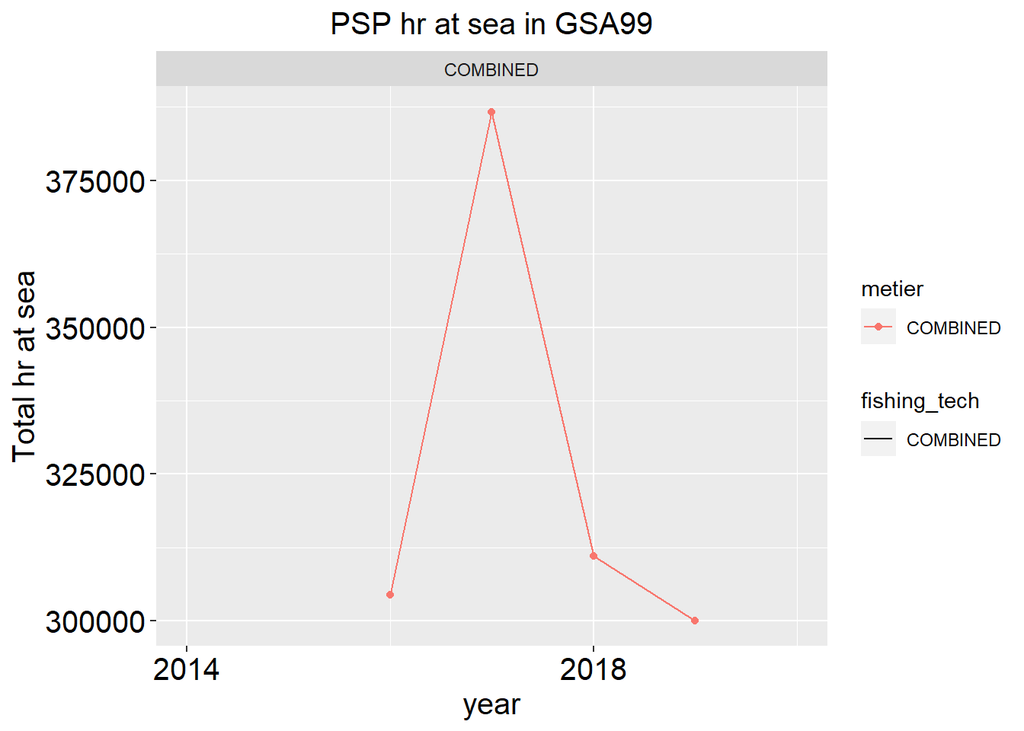

Plot of kW times hours at sea for PSP - GSA99

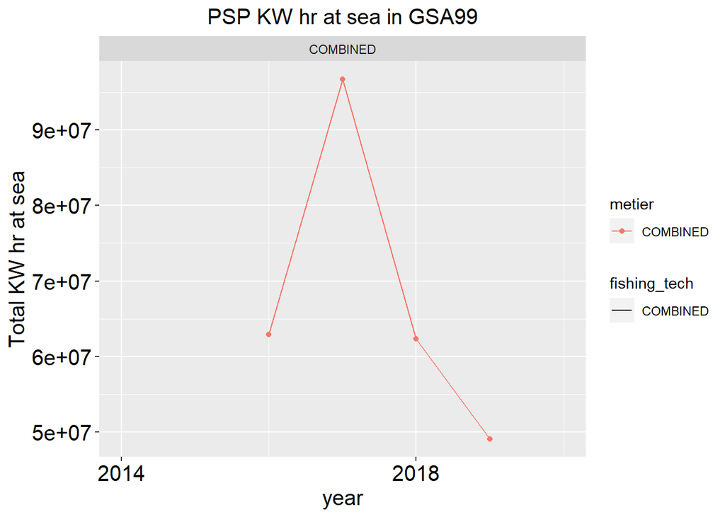

# 3 FDI Landings by rectangle data (table H)

## 3.1 Check the presence of empty fiels

FDI Landings by rectangle data (table H) were checked for the presence of not allowed empty records. In case empty data are detected, a list of fields with the number of empty records is reported.’

*Table of empty records in FDI Landings by rectangle table (Table H)*

|  | Empty_records |
| --- | --- |
| target_assemblage | 446 |
| specon_tech | 1138 |
| deep | 2426 |
| confidential | 2450 |

## 3.2 Check the presence of duplicated records

FDI Landings by rectangle data (table H) were checked for the presence of duplicated records. In particular, it was checks whether the combination of the first 20 columns generates duplicate records.’

- 21 duplicated record/s was/were detected in the FDI Landings by rectangle table H

*Table of duplicated records in FDI Landings by rectangle table (Table H)*

|  | country | year | quarter | vessel_length | fishing_tech | gear_type | target_assemblage | mesh_size_range | metier | sub_region | rectangle_type | rectangle_lat | rectangle_lon | c_square | species |
| --- | --- | --- | --- | --- | --- | --- | --- | --- | --- | --- | --- | --- | --- | --- | --- |
| 853 | PSP | 2017 | 1 | VL2440 | DFN | GNS | NK | DEF | GTR_DEF_>=16_0_0 | GSA99 | 05*05 | NA | NA | 1004:209:1 | SKJ |
| 881 | PSP | 2020 | 1 | VL1218 | DFN | GNS | NK | NK | NK | GSA99 | 05*05 | NA | NA | 1004:209:2 | YFT |
| 887 | PSP | 2014 | 1 | VL1824 | DFN | GNS | NK | NK | NK | GSA99 | 05*05 | NA | NA | 1004:209:2 | YFT |
| 888 | PSP | 2014 | 1 | VL2440 | DFN | GNS | NK | NK | NK | GSA99 | 05*05 | NA | NA | 1004:209:2 | BET |
| 923 | PSP | 2019 | 1 | VL2440 | DFN | GNS | 40D50 | SLP | GNS_SLP_>=16_0_0 | GSA99 | 05*05 | NA | NA | 1004:209:4 | SKJ |
| 924 | PSP | 2019 | 1 | VL0006 | DFN | GNS | 40D50 | SLP | GNS_SLP_>=16_0_0 | GSA99 | 05*05 | NA | NA | 1004:209:4 | YFT |
| 1091 | PSP | 2019 | 1 | VL1218 | DFN | GTR | 40D50 | DEF | GTR_DEF_>=16_0_0 | GSA99 | 05*05 | NA | NA | 1005:101:4 | SKJ |
| 1111 | PSP | 2014 | 1 | VL1218 | DFN | GTR | 40D50 | DEF | GTR_DEF_>=16_0_0 | GSA99 | 05*05 | NA | NA | 1005:102:1 | YFT |
| 1122 | PSP | 2015 | 1 | VL1824 | DFN | GTR | 40D50 | DEF | GTR_DEF_>=16_0_0 | GSA99 | 05*05 | NA | NA | 1005:102:1 | SKJ |
| 1161 | PSP | 2020 | 1 | VL1218 | DFN | GTR | 40D50 | DEF | GTR_DEF_>=16_0_0 | GSA99 | 05*05 | NA | NA | 1005:102:3 | BET |
| 1325 | PSP | 2020 | 1 | VL0612 | DFN | GTR | NK | DEF | GNS_DEF_>=16_0_0 | GSA99 | 05*05 | NA | NA | 1005:110:1 | SKJ |
| 1371 | PSP | 2019 | 1 | VL1218 | DFN | GTR | NK | DEF | GTR_DEF_>=16_0_0 | GSA99 | 05*05 | NA | NA | 1005:110:4 | YFT |
| 1389 | PSP | 2014 | 1 | VL0006 | DFN | GTR | NK | DEF | GTR_DEF_>=16_0_0 | GSA99 | 05*05 | NA | NA | 1005:111:1 | SKJ |
| 1420 | PSP | 2014 | 1 | VL0612 | DFN | GTR | NK | DEF | GTR_DEF_>=16_0_0 | GSA99 | 05*05 | NA | NA | 1005:111:2 | YFT |
| 1421 | PSP | 2014 | 1 | VL1218 | DFN | GTR | NK | DEF | GTR_DEF_>=16_0_0 | GSA99 | 05*05 | NA | NA | 1005:111:2 | BET |
| 1422 | PSP | 2014 | 1 | VL1824 | DFN | GTR | NK | DEF | GTR_DEF_>=16_0_0 | GSA99 | 05*05 | NA | NA | 1005:111:2 | SKJ |
| 1453 | PSP | 2014 | 1 | VL2440 | DFN | GTR | NK | DEF | GTR_DEF_>=16_0_0 | GSA99 | 05*05 | NA | NA | 1005:111:4 | SKJ |
| 1479 | PSP | 2018 | 1 | VL0006 | DFN | GTR | NK | DEF | GTR_DEF_>=16_0_0 | GSA99 | 05*05 | NA | NA | 1005:112:1 | BET |
| 1481 | PSP | 2018 | 1 | VL1218 | DFN | GTR | NK | DEF | GTR_DEF_>=16_0_0 | GSA99 | 05*05 | NA | NA | 1005:112:1 | YFT |
| 1499 | PSP | 2020 | 1 | VL0006 | DFN | GTR | NK | DEF | GTR_DEF_>=16_0_0 | GSA99 | 05*05 | NA | NA | 1005:112:2 | BET |
| 2366 | PSP | 2018 | 1 | VL1218 | HOK | LLS | NA | DEF | LLS_DEF_0_0_0 | GSA99 | 05*05 | NA | NA | 1004:209:1 | BET |